# How to Create Different Plot Types in R

Andrie de Vries and Joris Meys

The plot function in R has a type argument that controls the type of plot that gets drawn. For example, to create a plot with lines between data points, use type=“l”; to plot only the points, use type=“p”; and to draw both lines and points, use type=“b”:

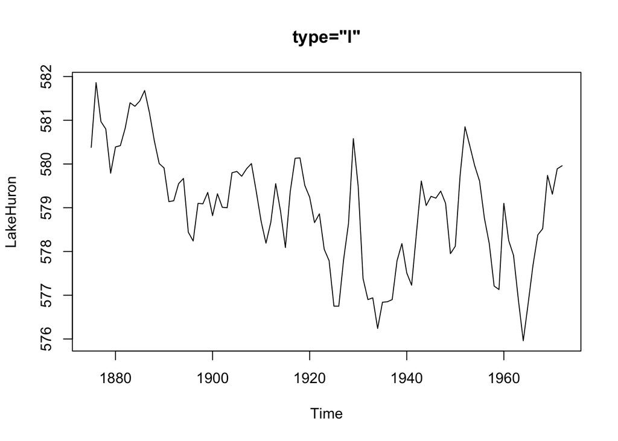

```r
plot(LakeHuron, type="l", main='type="l"')
```

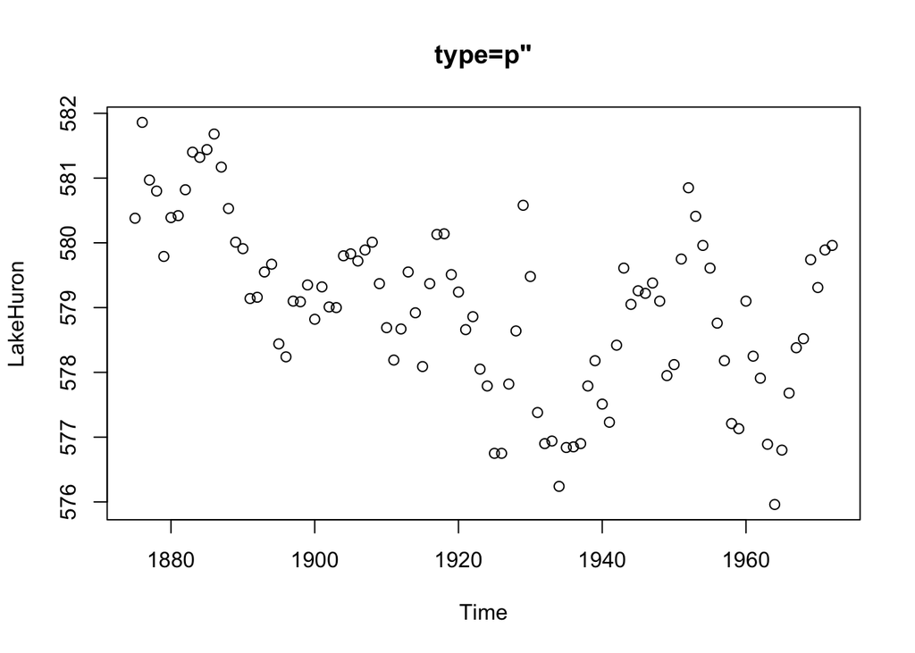

```r
plot(LakeHuron, type="p", main='type=p"')
```

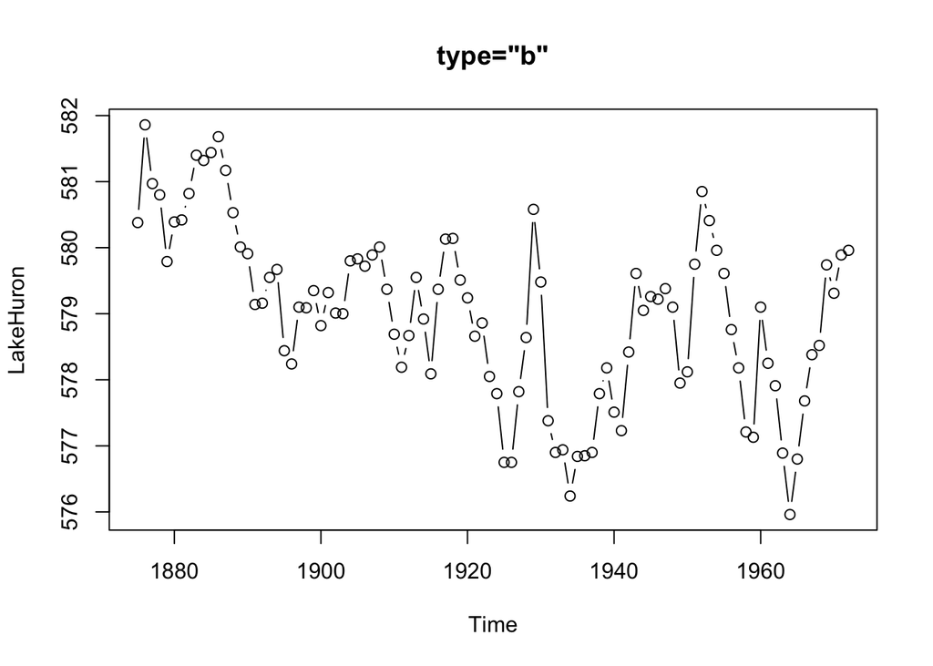

```r
plot(LakeHuron, type="b", main='type="b"')
```

The Help page for plot() has a list of all the different types that you can use with the type argument:

- **“p”**: Points
- **“l”**: Lines
- **“b”**: Both
- **“c”**: The lines part alone of “b”
- **“o”**: Both “overplotted”
- **“h”**: Histogram like (or high-density) vertical lines
- **“n”**: No plotting

It seems odd to use a plot function and then tell R not to plot it. But this can be very useful when you need to create just the titles and axes, and plot the data later using points(), lines(), or any of the other graphical functions.

This flexibility may be useful if you want to build a plot step by step (for example, for presentations or documents). Here’s an example:

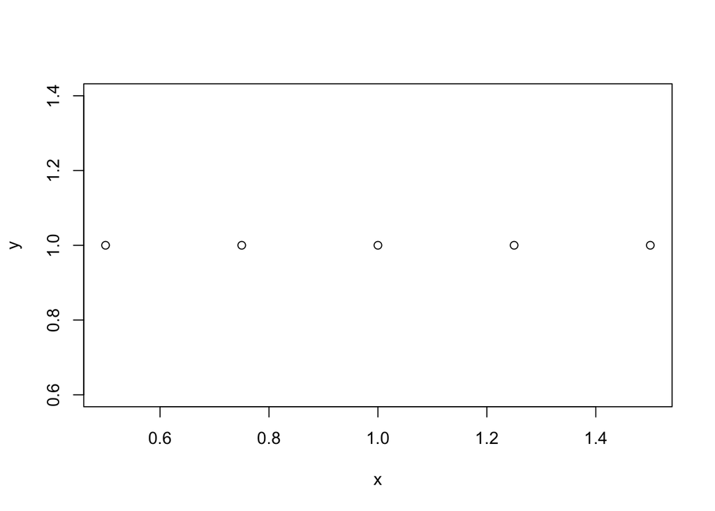

```r
 x <- seq(0.5, 1.5, 0.25)
 y <- rep(1, length(x))
 plot(x, y, type="n")
 points(x, y)
```

Aside from plot(), which gives you tremendous flexibility in creating your own plots, R also provides a variety of functions to make specific types of plots. Here are a few to explore:

- **Scatterplot:** If you pass two numeric vectors as arguments to plot(), the result is a scatterplot. Try:

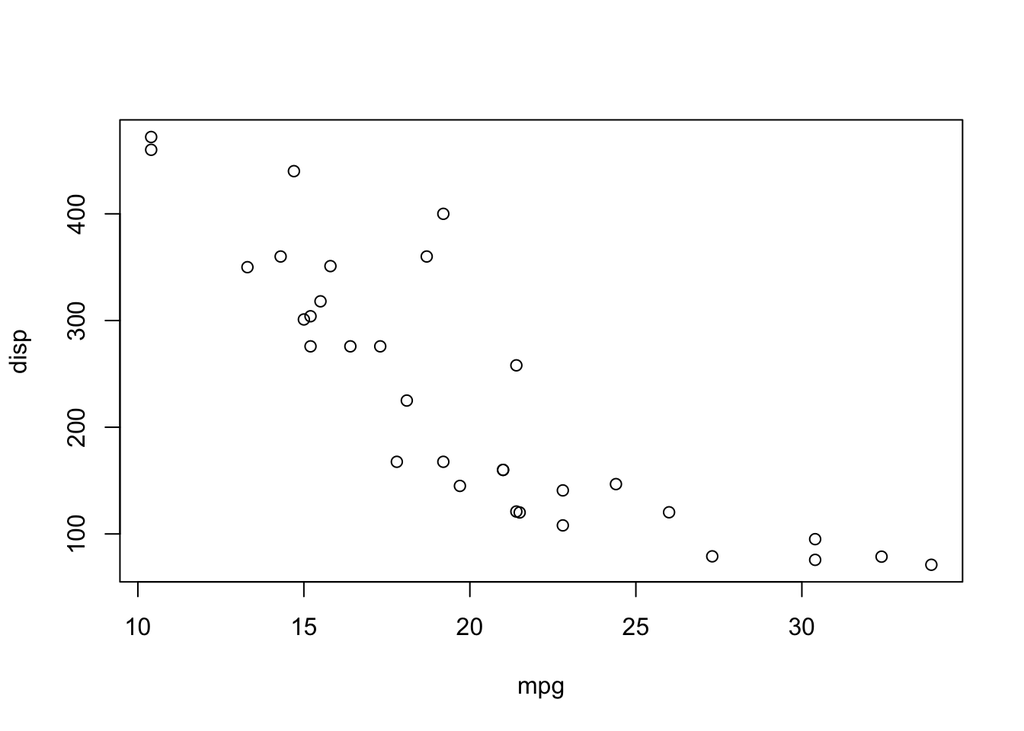

```r
with(mtcars, plot(mpg, disp))
```

- **Box-and-whisker plot:** Use the boxplot() function:

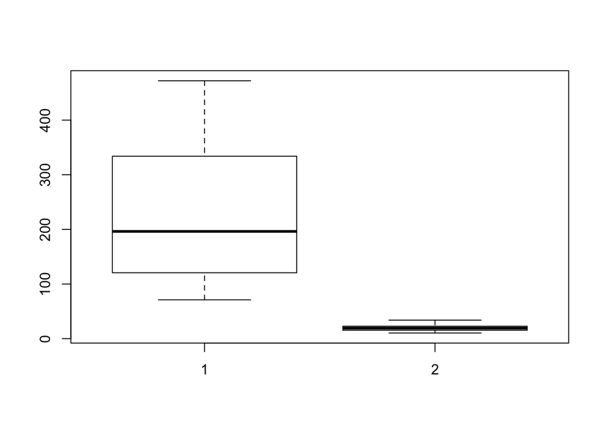

```r
with(mtcars, boxplot(disp, mpg))
```

- **Histogram:** A histogram plots the frequency of observations. Use the hist() function:

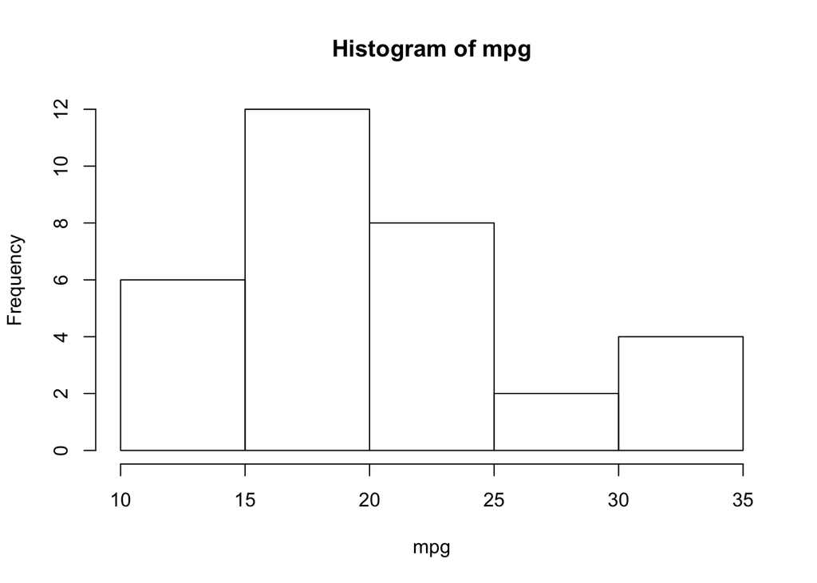

```r
with(mtcars, hist(mpg))
```

- **Matrix of scatterplots:** The pairs() function is useful in data exploration, because it plots a matrix of scatterplots. Each variable gets plotted against another.

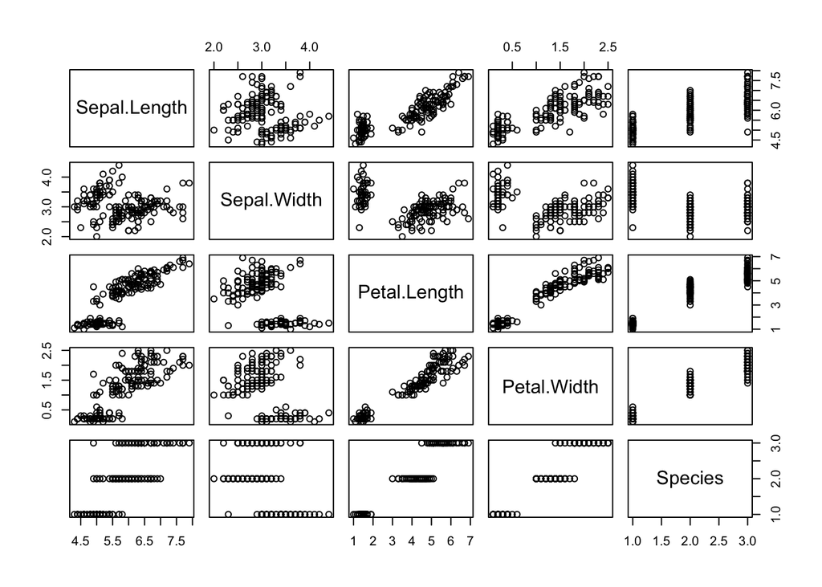

```r
 pairs(iris)
```

[More information](http://www.dummies.com/how-to/content/how-to-create-different-plot-types-in-r.html)